# MICE Encoding: Fixed Model

Kyle Kurkela

2018-01-30

Welcome to the MICE Encoding: Fixed Model notebook!

In this notebook, I will be presenting the results of a “fixed” model (`MixedBlockER_TwoParMods_NRs_removed`) for MICE encoding and contrasting them with the previously misspecified model (`MixedBlockER_TwoParMods`).

# Behavior refresher

Recall, the subsequent memory performance of our sample looks like this:

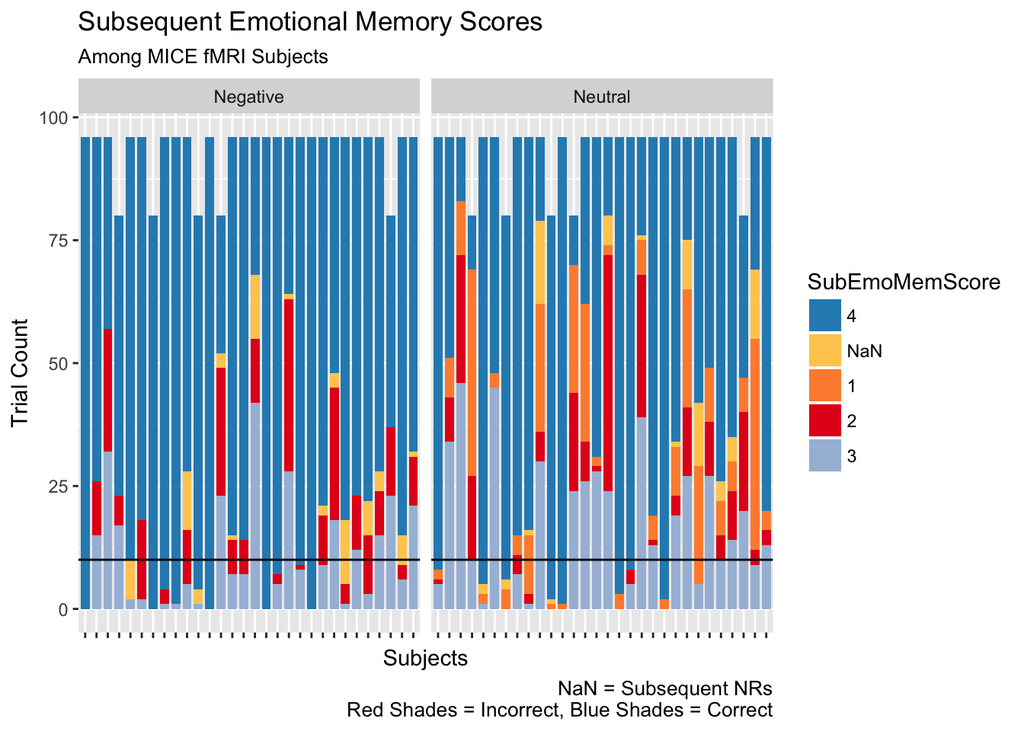

```r
tidy.df <- read.csv("./data/trial-counts.csv")

tidy.df %>%
  mutate(
    SubEmoMemScore = factor(SubEmoMemScore, levels = c("4", "NaN", "1", "2", "3"))
  ) %>%
  ggplot(aes(x = subject, fill = SubEmoMemScore)) +
  geom_bar(position = "stack", width = .8) +
  facet_grid(~Emotion) +
  theme(axis.text.x = element_blank()) +
  xlab("Subjects") +
  ylab("Trial Count") +
  ggtitle("Subsequent Emotional Memory Scores", subtitle = "Among MICE fMRI Subjects") +
  labs(caption = "NaN = Subsequent NRs\nRed Shades = Incorrect, Blue Shades = Correct") +
  scale_fill_manual(values=c("#2b8cbe", "#fecc5c", "#fd8d3c", "#e31a1c", "#a6bddb")) +
  geom_hline(yintercept = 10, color = "black")
```

Note: the big change between the ‘Misspecified’ model and the new ‘fixed’ model is dealing with the NaN’s in the figure above. Explained below.

# The ‘Misspecified’ Model

The model that I presented in Joint Lab meeting was **misspecified**. The previous model gave the relatively rarely occuring `subsequent NR` trial type a score of 0. This should NOT be the case; these trials should be “ignored” in the same way that neutral trials are ignored for the NegDM parametric regressor and negative trials for the NeuDM parametric regressor.

The new ‘fixed’ model now ignores subsequent NRs when creating the Difference in Memory (DM) parametric modulators.

`sub-s011`’s behavior looks like this:

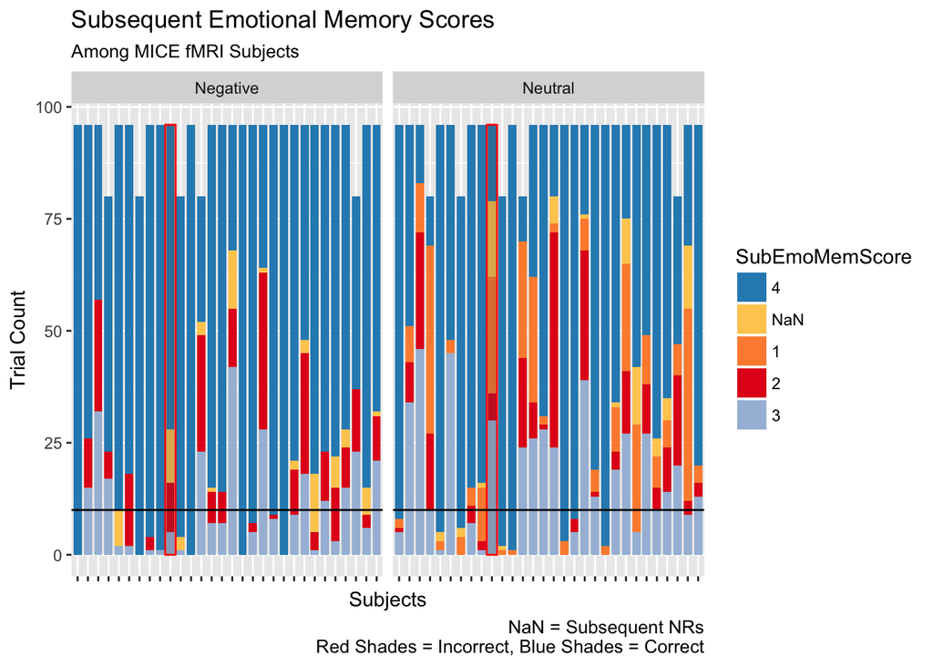

As you can see, `sub-s011` has a good number of both subsequent Emotional NRs and subsequent Neutral NRs. The effects of the fixed model should effect subjects with lots of subsequent NRs.

`sub-s011`’s design matrix before and after:

[video not shown]

I choose this subject because they have a number of both Emotional and Neutral Subsequent NRs.

I know what you are saying: those parametric modulators look almost identitical. I double checked my code and I am sure that this is correct. Looking at the orthongality plot in SPM, these regressors are all co-linear (cosine values > .9).

How does this effect the results we looked at?

# Results

## Transient

First, lets read it the data and clean it up

```r
read.csv('data/roi-results.csv') %>%
  mutate(hemisphere = ifelse(grepl("[L]{1}", roi_name), "L", ifelse(grepl("[R]{1}", roi_name), "R", NA)),
         hemisphere = ifelse(hemisphere == "L", "Left", ifelse(hemisphere == "R", "Right", NA)),
         hemisphere = factor(hemisphere),
         region     = roi_name,
         region     = sub("^r", "", region), # remove the leading "r"
         region     = sub("_[LR]{1}_mask$", "", region), # remove the trailing "_L/R_mask"
         region     = factor(region, levels = c("AMY", "PRC", "HIPP_BODY", "HIPP_HEAD", "PHC_ANT"))
         ) -> df
```

### MTL ROIs

Below are the new results within our MTL Regions of Interest.

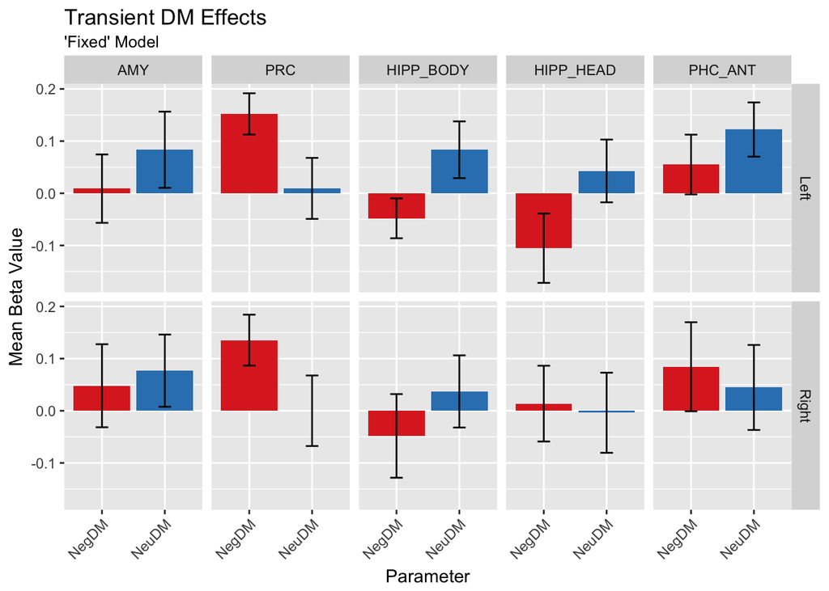

```r
df %>%
  ggplot(aes(x = con_name, y = summary_value, fill = con_name)) +
    geom_bar(stat = "summary",
             fun.y = "mean") +
    geom_errorbar(stat = "summary",
                  fun.data = "mean_se",
                  width = 0.2) +
    facet_grid(hemisphere~region) +
    theme(axis.text.x = element_text(angle = 45, hjust = 1)) +
    labs(y = "Mean Beta Value",
         x = "Parameter",
         title = "Transient DM Effects",
         subtitle = "'Fixed' Model") +
    scale_x_discrete(limits = c("NegDM", "NeuDM")) +
    scale_fill_manual(guide=FALSE, values = c("#de2d26", "#3182bd"))
```

Run a `hemisphere` (right/left) x `Parameter` (NegDM/NeuDM) ANOVA on each region.

```r
regions <- levels(df$region)

for(cregion in regions){

  df[df$region == cregion,] %>%
    filter(grepl("DM", con_name)) -> c.region.df

  ezANOVA(data = c.region.df
          , dv = summary_value
          , wid = subject_id
          , within = .(con_name, hemisphere)
  ) -> results

#  if(any(results[[1]]$`p<.05` != '')){
    print(paste("Region:", cregion))
    print(results)
#  }
}
```

```
## [1] "Region: AMY"
## $ANOVA
##                Effect DFn DFd         F         p p<.05          ges
## 2            con_name   1  17 0.4031956 0.5338973       0.0075297652
## 3          hemisphere   1  17 0.1629775 0.6914627       0.0007471118
## 4 con_name:hemisphere   1  17 0.7570993 0.3963581       0.0014786398
##
## [1] "Region: PRC"
## $ANOVA
##                Effect DFn DFd          F          p p<.05          ges
## 2            con_name   1  17 3.62488235 0.07398972       8.707189e-02
## 3          hemisphere   1  17 0.17519131 0.68077892       8.384860e-04
## 4 con_name:hemisphere   1  17 0.02176214 0.88445711       6.702264e-05
##
## [1] "Region: HIPP_BODY"
## $ANOVA
##                Effect DFn DFd         F         p p<.05         ges
## 2            con_name   1  17 1.7810557 0.1996204       0.042328695
## 3          hemisphere   1  17 0.2434794 0.6280182       0.002031514
## 4 con_name:hemisphere   1  17 0.3469059 0.5636153       0.002003520
##
## [1] "Region: HIPP_HEAD"
## $ANOVA
##                Effect DFn DFd          F           p p<.05         ges
## 2            con_name   1  17  0.5069718 0.486110212       0.012874794
## 3          hemisphere   1  17  1.8099266 0.196189090       0.003999535
## 4 con_name:hemisphere   1  17 11.5664558 0.003400785     * 0.020552307
##
## [1] "Region: PHC_ANT"
## $ANOVA
##                Effect DFn DFd          F         p p<.05          ges
## 2            con_name   1  17 0.01657372 0.8990750       0.0005562983
## 3          hemisphere   1  17 0.26268071 0.6148791       0.0017117031
## 4 con_name:hemisphere   1  17 1.61869644 0.2204016       0.0083493451
```

## Sustained

Below are the updated results for the sustained regressors:

### MTL ROIs

Below are the new results within our MTL Regions of Interest.

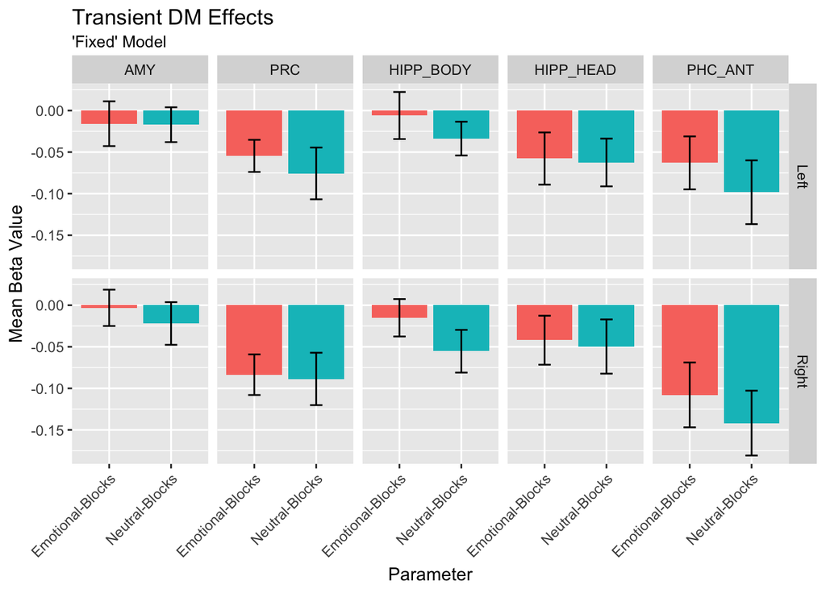

```r
df %>%
  ggplot(aes(x = con_name, y = summary_value, fill = con_name)) +
    geom_bar(stat = "summary",
             fun.y = "mean") +
    geom_errorbar(stat = "summary",
                  fun.data = "mean_se",
                  width = 0.2) +
    facet_grid(hemisphere~region) +
    theme(axis.text.x = element_text(angle = 45, hjust = 1)) +
    labs(y = "Mean Beta Value",
         x = "Parameter",
         title = "Transient DM Effects",
         subtitle = "'Fixed' Model") +
    scale_x_discrete(limits = c("Emotional-Blocks", "Neutral-Blocks")) +
    scale_fill_discrete(guide=FALSE)
```

Run a `hemisphere` (right/left) x `Parameter` (Emotional-Blocks/Neutral-Blocks) ANOVA on each region:

```r
regions <- levels(df$region)

for(cregion in regions){

  df[df$region == cregion,] %>%
    filter(grepl("Blocks", con_name)) -> c.region.df

  ezANOVA(data = c.region.df
          , dv = summary_value
          , wid = subject_id
          , within = .(con_name, hemisphere)
  ) -> results

#  if(any(results[[1]]$`p<.05` != '')){
    print(paste("Region:", cregion))
    print(results)
#  }
}
```

```
## [1] "Region: AMY"
## $ANOVA
##                Effect DFn DFd          F          p p<.05          ges
## 2            con_name   1  17 0.20646859 0.65529766       0.0025719941
## 3          hemisphere   1  17 0.05897076 0.81103590       0.0003866742
## 4 con_name:hemisphere   1  17 3.79578399 0.06808601       0.0019844927
##
## [1] "Region: PRC"
## $ANOVA
##                Effect DFn DFd         F         p p<.05         ges
## 2            con_name   1  17 0.4021911 0.5344014       0.003421194
## 3          hemisphere   1  17 1.7301099 0.2058625       0.008797169
## 4 con_name:hemisphere   1  17 1.1218157 0.3043457       0.001290299
##
## [1] "Region: HIPP_BODY"
## $ANOVA
##                Effect DFn DFd        F         p p<.05          ges
## 2            con_name   1  17 2.031425 0.1721784       0.0277792520
## 3          hemisphere   1  17 1.004186 0.3303511       0.0058087919
## 4 con_name:hemisphere   1  17 2.193254 0.1569126       0.0009676938
##
## [1] "Region: HIPP_HEAD"
## $ANOVA
##                Effect DFn DFd          F         p p<.05          ges
## 2            con_name   1  17 0.06060067 0.8084968       6.021972e-04
## 3          hemisphere   1  17 1.37458880 0.2571933       3.181329e-03
## 4 con_name:hemisphere   1  17 0.16764145 0.6873291       3.265386e-05
##
## [1] "Region: PHC_ANT"
## $ANOVA
##                Effect DFn DFd           F          p p<.05          ges
## 2            con_name   1  17 1.453545790 0.24447331       1.257551e-02
## 3          hemisphere   1  17 4.676037909 0.04513221     * 2.039217e-02
## 4 con_name:hemisphere   1  17 0.008664134 0.92692714       5.151217e-06
```